# Module 3 Lecture - Biopsychology

Introductory Psychology

Quinton Quagliano, M.S., C.S.P

Department of Psychology

# 1 Overview and Introduction

Agenda

1 Overview and Introduction

2 Human Genetics

3 Cells of the Nervous System

4 Parts of the Nervous System

5 The Brain and Spinal Cord

6 The Endocrine System

7 Conclusion

## 1.2 Instructor Learning Objectives

- Understand the purpose on learning anatomy to contextualize human behavior and cognition
- Appreciate the complexity in our nervous system processes and how the interact to rise to cognition

## 1.3 Introduction

- Brains and nerves are strange things, but they are the biological basis for our thoughts and behaviors - so it behooves us to study and >understand them
- This module will help introduce the many physiological and anatomical processes that are associated with what we do, think, and feel
- **Discuss: There is a broader philosophical debate on whether humans are purely biological and chemical beings, i.e., do we have a soul? or are we just being driven by chemical equations and processes - what do you think?**

# 2 Human Genetics

Agenda

1 Overview and Introduction

2 Human Genetics

3 Cells of the Nervous System

4 Parts of the Nervous System

5 The Brain and Spinal Cord

6 The Endocrine System

7 Conclusion

## 2.1 Introduction

- Our genetics are the traits we inherit from our biological parents, that play into the specific and unique code that make up the basis of cells in our body
  - In this case, I’m using “parents” to refer to those who contribute the gametes, i.e., sperm and egg, that create the zygote
- Understandably, genetics play a very important role in our physical health and characteristics, but also are associated with our psychological make-up as well
  - A basic physical example: height - if you have two tall parents, you are likely to be tall, if you have two shorter parents, you are likely to be short
  - A psychological example: If both of your parents have bipolar disorder, are you more likely to? It’s complicated…

## 2.2 Genetic Variation

- Variation in our genetics contributes to the individual differences that we notice between each person
  - Our hair, skin, and eye color
  - The dimensions and structure of our face
  - Heritable diseases or conditions
- **Discuss: What are some other examples of physical/mental traits that are genetic, i.e., passed down by parents?**
- The specific variation that each person has is a function of the sperm and egg cells that come together at the beginning of pregnancy
  - Both the egg and sperm cells have 23 **chromosomes** made up of **DNA**, the building blocks of our being
  - The sperm and egg cells combine for a total of 46 chromosomes into a zygote, which has a specified **genotype**, or genetic make up. That genotype contributes to the **phenotype**, or the apparent physical characteristics that manifest.
  - Specific sequences and sections of that DNA make up **genes**, which function sort of like switches that produce certain outcomes. These genes can be in different variations, or **alleles**, thus resulting in different effects
- Most physical traits are complex and result from multiple different genes, which would be called **polygenic** traits
  - However some genes are slightly simpler, such as having a cleft chin, in which there is only one gene that contributes.
  - Having two of the same allele from both parents is called **homozygous**, whereas having two different alleles is referred to as being **heterozygous.**
  - A **dominant** allele is one that “overrides” a **recessive** allele to become the phenotype; a recessive allele will only reflect in a phenotype if both alleles are recessive.

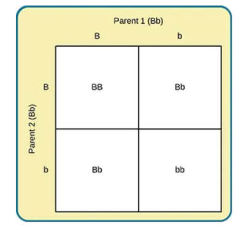

- **Mutation** comes from a sudden and change to the genes that result in unexpected changes to the genotype - which could manifest as disadvantageous, deadly, or useful phenotypes
- **Question: Mutation can lead to increased 'fitness' or ability to adapt / survive. Which psychological perspective would focus intensely on this, outside of biopsychology?**
- A) Cogntive
- B) Beharvioral
- C) Gestalt
- D) Evolutionary

## 2.3 Gene-Environment Interactions

- Genes are not absolutely deterministic - while they do have a meaningful impact, they only explain one part of our being
- **Important: There are several different perspective on how genes and the environment interact with one another - carefully consider the following as different perspectives, and think about which you may align with**
- Genes can understood as setting a **range of reaction**, or effectively, a range of possible outcomes based on our environment. This means that genes, in a way, express what our potential is.
  - It is believed that our environment plays into how much of that potential is realized or not
- Others may posit that genes and the environment are correlated , so that our genes drive us towards a certain environment, which in turn reinforces a certain expression of our genes
  - This sort of bidirectional relationship means that both our genes and environment play an equal role in our outcomes
- Yet another perspective comes from the field of **epigenetics**, which is concerned with how the same genotype can give rise to different phenotypes, as a result of our environment
  - Example: instructor’s identical twin
- Many students are introduced to genes by studying and practicing on physical characteristics, largely because they are relatively easy to identify and measure
  - However, genes also play a role in the mental, like our intellect, mental health, personality, etc.
  - But, given the complexity of mental characteristics, the direct impact of genes can be much harder to parse out
- This section is connected to the concept of **nature vs. nurture**, something we will revisit during the developmental psychology module

# 3 Cells of the Nervous System

Agenda

1 Overview and Introduction

2 Human Genetics

3 Cells of the Nervous System

4 Parts of the Nervous System

5 The Brain and Spinal Cord

6 The Endocrine System

7 Conclusion

## 3.1 Introduction

- The human nervous system is comprised of two types of specialized cells:
  - The **neuron**: which is the essential communication unit which conveys signals to other neurons and organs
  - The **glial cell**: which supports neurons cell functions
- There is roughly an equal amount of these two types of cells through the nervous system in humans
  - Give or take, around 100 billion neurons in an adult brain

## 3.2 Neuron Structure

- A neuron is a specialized cell that has a **semi-permeable membrane** allowing certain molecules to pass through its outer surface to create a charge

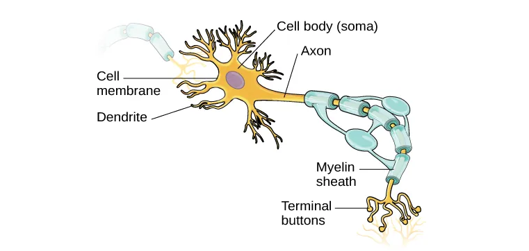

- The elongated **axons** are covered in a **myelin sheath**, separated by **Nodes or Ranvier**. The myelin sheath serves a purpose to modify and preserve the special electric signal traveling through the axon.
  - Diseases such as Multiple sclerosis are called “demyelinating diseases” because they degrade this insulation, which has compounding negative physical impacts
- The **terminal buttons** at the end of each neuro contains **synaptic vessels**, which in turn, have **neurotransmitters** that serve as a method of communication with other neurons’ dendrites.
  - When a charge travels down the length of the axon, it triggers actions in the terminal buttons
- When triggered, neurotransmitters are released into the **synaptic cleft**, between the synaptic vessels of the transmitting neuron, and the dendrites with **receptors** on the receiving neuron(s)
  - Specific neurotransmitter bind to specific sites on the receptors, like a key going into a keyhole

## 3.3 Neuronal Communication

- **Important: Get ready for some light chemistry y'all - from your chemistry-incompetent instructor**
- A signal from the neuron is created by a **membrane potential** resulting from a change in concentration of charged particles across the semi-permeable membrane
- At a baseline, the neuron holds a **resting potential** where there is an imbalance of charged particles on one side of the membrane, so that the neuron remains “ready” to fire
  - The primary particles for us to pay attention to are the positively-charged sodium ions (Na+) and the positively-charged potassium ions (K+), and their relative concentrations inside and outside the cell

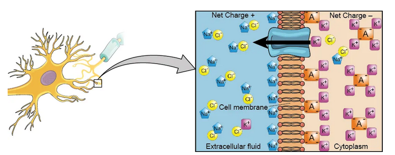

- The neuron receives a signal via it dendrites, and quickly undergoes rapid change to allow an influx of Na+, greatly increasing the positive energy of the cell - this is an **all-or-nothing** process

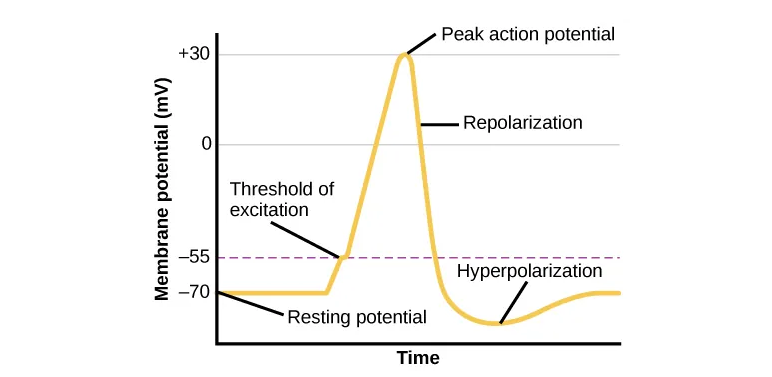

- The action potential reaches the terminal buttons, triggering neurotransmitters to push into the synaptic cleft, where they are received by other neurons, which in turn push their own action potential
  - Unused particles in the synaptic cleft return to the original neuron, during **reuptake**

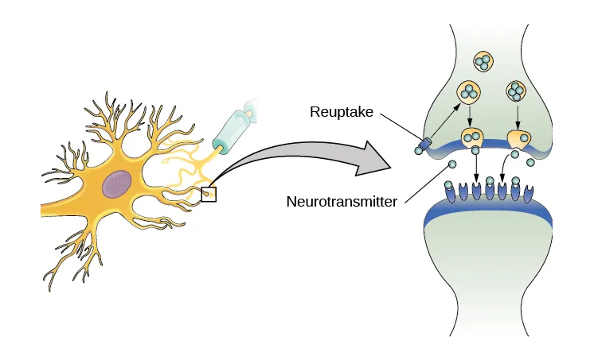

## 3.4 Neurotransmitters and Drugs

- There are many types of neurotransmitters, which serve distinct purposes and are launched for specific types of signals

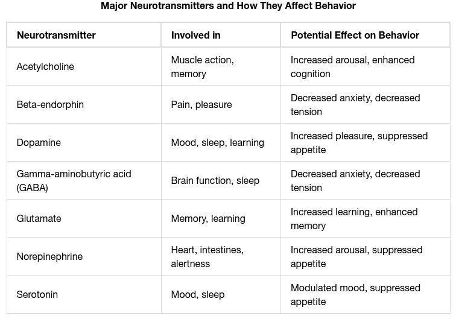

- Certain medication work to modify behavior in the synaptic cleft:
  - **Agonist** medications mimic and recreate neurotransmitters so that neurons recieve greater signals
  - **Antagonists** block binding of neurotransmitters to receptors to prevent over-consumption
  - **Reuptake inhibitors** prevent reuptake, to help certain neurotransmitter remain longer in the cleft

# 4 Parts of the Nervous System

Agenda

1 Overview and Introduction

2 Human Genetics

3 Cells of the Nervous System

4 Parts of the Nervous System

5 The Brain and Spinal Cord

6 The Endocrine System

7 Conclusion

## 4.1 Introduction

- The human nervous system is described between two connected systems:
  - The **central nervous system (CNS)** housing The Brain and Spinal Cord
  - The Peripheral Nervous System (PNS), which is basically everything else in the body that connects back to the CNS

## 4.2 Peripheral Nervous System (PNS)

- The peripheral nervous system has bundles of axons called **nerves** which ensure signals from our body are carried to the spine and brain for messaging
- Within the PNS there are two furtherdivisions:
  - The **somatic nervous system**, which deals with conscious or voluntary actions, such as most movements
  - The **autonomic nervous system**, which is related to involuntary and automatic processes like organ control.
- The somatic nervous system will contain efferent neurons that are exiting from the CNS to deliver messages to PNS, to do things like move muscles.
  - On the other hand, there are afferent neurons that carry sensory signals back into the CNS to be received in the brain and spinal cord
- The autonomic nervous system has two divisions in it as well, the **parasympathetic** and **sympathetic nervous systems**

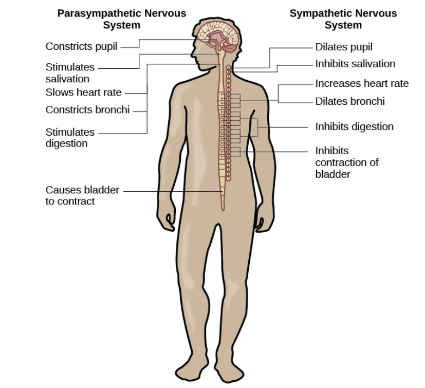

- **Question: Which action would be most associated with the sympathetic nervous system?**
- A) Talking to a friend casually
- B) Your stomach processing food
- C) Your hand sending a signal of pain due to being put on a stove
- D) Running from a lion

# 5 The Brain and Spinal Cord

Agenda

1 Overview and Introduction

2 Human Genetics

3 Cells of the Nervous System

4 Parts of the Nervous System

5 The Brain and Spinal Cord

6 The Endocrine System

7 Conclusion

## 5.1 Introduction

- Making up the CNS, the brain and spinal cord serve essential, core functions in the control and regulation of our body.
  - The brain can be understood as integrating the many different signals, messages, and commands that the body must follow - and has a necessarily complex layout to help accomplish this!

## 5.2 The Spinal Cord

- The spinal cord is the highway and relay station that receives signals from the PNS, but also transmit signals from the brain to the PNS
- It also has it’s own built-in system of **reflexes**, which can act without input from the brain
- **Discuss: What is an example of a reflex you can think of?**
- The spine is segmented by vertebrae (bones) and has two types of nerve bundles exiting from it, **sensory** nerves which are ready to receive information and **motor** nerves which connect to muscles and send signals to move

## 5.3 Neuroplasticity

- Injury or problems in development of the CNS can lead to extensive deficits in cognition and functioning
  - However, our CNS (and body in general) has a remarkable ability to compensate and adapt to damage - this is called **neuroplasticity**
- As a rule of thumb, our brains are able to adapt the best when we are young, as our brains are still developing.
  - As we age, our neuroplasticity decreases, but some repair is still possible.
  - Neuroplasticity is why some folks can recover a surprising amount of skills after brain damage

## 5.4 The Two Hemispheres

- The outside surface of the brain is the **cerebral cortex**, which many uneven grooves and ridges, which allow are cortex to have a large surface area.
  - The bumps are called **gyri** and the valleys in between **sulci**, with the most prominent sulcus being the longitudinal fissue that bisect the brain into a left and right half, or **hemisphere**

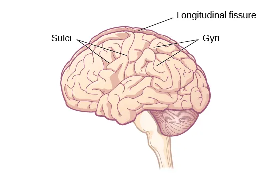

- There is reasonable evidence that certain skills and functions are somewhat localized to a specific region or hemisphere of the brain
  - As a somewhat reductionist example: the left hemisphere generally is more associated with positive emotions and the right hemisphere, more associated with negative emotions
- **Important: One should be cautious in definitively saying that certain functions only ever exist on one side of the brain - especially on an individual basis**
- The hemispheres are connected via the neuron bundle of the **corpus callosum**, which allow communication between the otherwise separate halves of our brain
  - In some cases, this connection may be surgically resected or may not develop at all!
  - If the corpus callosum does not form, it results in “split-brain”-ness, which can manifest as poor coordination between separate cognitive skills that are partially lateralized.
- Ironically, most research on the brain’s more focal functions is done on individuals that have suffered damage to that area of the brain, and show symptoms that suggest what cognitive abilities may be related to the damaged area

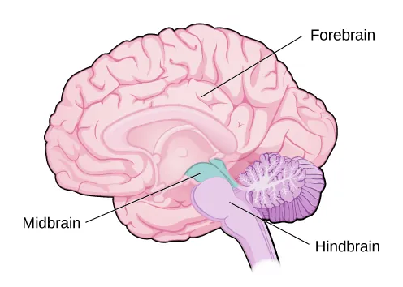

## 5.5 Forebrain Structures

- The **forebrain** is the physically largest part of the brain, visible on the top, front, and most of the side of the brain, and covers the more inner portions
- The following sections will cover the individual components of the forebrain

## 5.6 Lobes of the Brain

- The outermost layer of the forebrain, with the gyri and sulci, is called the **cerebral cortex**, and can be separated into 4 distinct **lobes:**
  - The **frontal lobe**
  - The **parietal lobe**
  - The **occipital lobe**
  - The **temporal lobe**

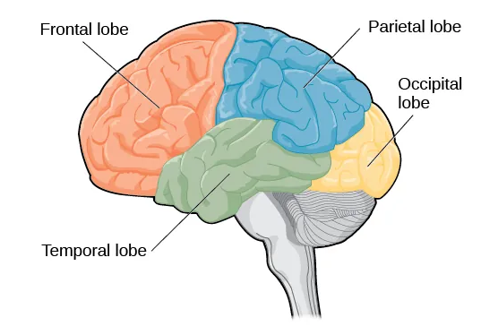

- The frontal lobe is in the front of the brain, behind the forehead.
  - It is generally involved in “higher-order” processing, intentional movement, language, and emotion
  - There are three particularly important areas usually in this area:
    - **The motor cortex** which communicates signals to move
    - The **prefrontal cortex** which is involved in reasoning and decision-making
    - **Broca’s area**, which is necessary for the production of speech
- **Question: A person suffers damage to their Broca's area in the frontal lobe. What activity are they likely to find difficult?**
- A) Quickly verbally naming off animals
- B) Pointing to dots on a page
- C) Recreating a drawing
- D) Listening to and following complex instructions
- Damage to these area (or the frontal cortex as a whole), is likely to disrupt these functions (see Phineas Gage)

[figure not shown]

- The **parietal lobe** is primarily used for integration of sensory information via the **somatosensory cortex** - info such as temperature, pain, pressure, etc. is understood here
- **Question: Review: If we are talking about integrating separate sensory information into a single comprehensive perceptual experience, what historical orientation would be most interested in this area?**
- A) Structuralism
- B) Functionalism
- C) Behaviorism
- D) Gestalt

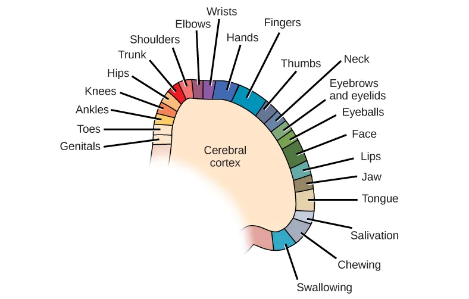

- The **temporal lobe** is to each side of the head, and closely related to hearing and memory.
  - It contains the **auditory corex** which processes incoming auditory information, and the **Wernicke’s area**, which deals in speech comprehension.
- Finally, **occipital lobe** is at the back of the brain and is responsible for integrating visual information

## 5.7 Other Areas of the Forebrain

- Underneath the forebrain are the **subcortical structures** that also serve important roles in cognition
- The **thalamus** handle routing information about senses (except smell) to the correct areas of the cortex for further processing
- The **limbic system** is made up of several different components, all related to emotion and memory.
  - The **hippocampus** is used for learning and memory
  - The **amygdala** is necessary for connecting memory and emotions
  - The **hypothalamus** helps regulate homeostatis, especially via sending signals to The Endocrine System.
- **Question: A child runs away from their parent across a busy street, a very poor and dangerous decision - what are of the brain is likely undeveloped in the child?**
- A) Thalamus
- B) Hypothalamus
- C) Prefrontal Cortex
- D) Somatosensory Cortex

## 5.8 Midbrain and Hindbrain Structures

- The **midbrain** rests below the forebrain, and in front of the **hindbrain**.
  - The **reticular formation** extend all the way to the edge of the forebrain, and goes down to the start of the hindbrain - it plays an important role in alertness, sleep, and arousal
  - The **substania nigra** and **ventral tegmental area (VTA)** indirectly help ensure movement goes smoothly, by producing the dopamine neurotransmitter
    - These structures become degraded in Parkinson’s disease, contributing to the movement problems associated with that disorder

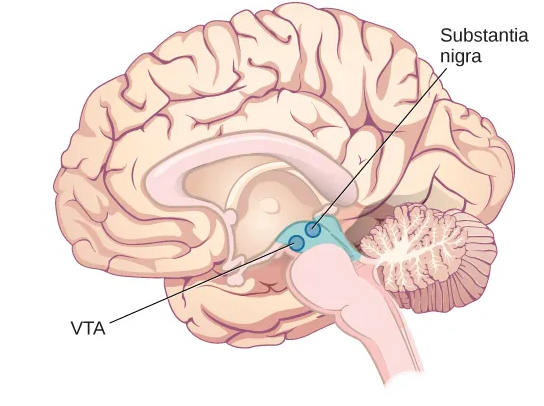

- The **hindbrain** is effectively the connecting point between the spine and brain, and contains several specific structures
  - The **medulla oblongata** (also just called the medulla) handles essential breathing, blood pressure, and heart rate
  - The **Pons** is most involved in regulation of sleep
  - The **Cerebellum** hangs of the back of the brainstem, and mostly helps coordination, balance, proprioception - but also some motor-based procedural memory

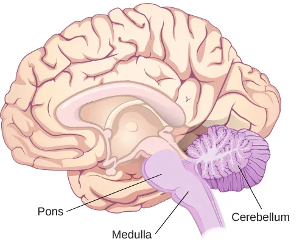

## 5.9 Brain Imaging Introduction

- Brain imaging has advanced greatly in the last several decades; which has allowed researchers to establish a much better understanding of structural change in the brain while a person is still alive
  - While autopsy was always an option, it was/is difficult to see how the brain works when it is non-functioning

## 5.10 Techniques Involving Radiation

- A **Computerized tomography (CT)** scan is effectively a series of x-rays across the layers of the brain, eventually resulting in a complete image of the brain structures
  - This was one of the earliest technologies to scan brains, and continues to see use today despite being less detailed than MRIs.
- A **Positron emission tomography (PET)** uses a radioactive “tracer” that flows with the blood in the brain to determine how certain areas “activate” i.e., get more blood - it is not used as much on it’s own now, given that it can’t visualize structure very well, but is sometimes used in conjunction with CTs.
- **Discuss: If a CT scan is less detailed that newer methods, why do you think it would be used so commonly?**

## 5.11 Techniques Involving Magnetic Fields

- **Magnetic Resonance Imaging (MRI)** uses the existing hydrogen within us and a magnetic field to detect tissue density and visualize structures.
  - In concept, they produce a similar static, structural image of the brain as a CT scan, but are more detailed.
- **Functional magnetic resonance imaging (fMRI)** are even more detailed and show activity over time in the brain, much like with a PET scan, but with far more structural detail at the same time.
  - Like with PET scans, fMRIs use blood flow to track movement, but also use the MRI structural imaging at the same time
- **Discuss: Why don't we just do fMRIs on everyone to check how healthy people's brain are? What barriers exist to that plan?**

## 5.12 Techniques Involving Electrical Activity

- **Electroencephalography (EEG)** scans use electrodes on the skull to track electrical activity in certain areas of the brain
  - Used a conductive gel and skull cap, and the individual electrodes can show areas of relatively high and low energy
  - Especially useful in sleep and epilepsy analysis, as it can be useful to see what areas of the brain are showing an excess or absence of activity

# 6 The Endocrine System

Agenda

1 Overview and Introduction

2 Human Genetics

3 Cells of the Nervous System

4 Parts of the Nervous System

5 The Brain and Spinal Cord

6 The Endocrine System

7 Conclusion

## 6.1 Introduction

- The **endocrine system** is responsible for the creation and regulation of chemical **hormones** throughout the body.
  - Hormones do not travel via neuron action potentials, but instead travel in the bloodstream, having systemic effects across the body
  - The **hypothalamus** (in the CNS) and the pituitary gland (of the endocrine system) work together to ensure hormones are in the correct concentration - as imbalance can be harmful/dangerous

## 6.2 Major Glands

- **Important: Dysfunction in any of these glands can cause major disruption to mood, fatigue, and other mental functions**
- The **pituitary gland** serves as the oversight to all the hormone creation occurring in the other endocrine system glands, working on instructions from the hypothalamus
  - It coordinates how the instructions are sent and carried to the other glands
- The **thyroid gland** plays an important role in regulating growth, metabolism, and appetite
- The **adrenal glands** appropriately produces epinephrine and norepinephrine, to control our adrenaline levels
- The **pancreas** is responsible for regulation of blood sugar and insulin throughout the body
  - Poor regulation in the pancreas or it’s products results in **diabetes**, meaning the additional intervention must be taken by the person or medicine to maintain homeostasis.
- The **gonads** are sex-specific, and create hormones appropriate to the sexual function of the gametes that are produced in one’s body

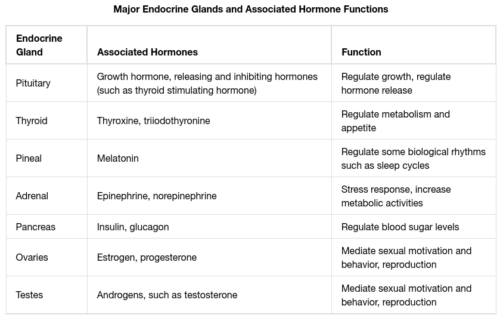

- **Question: Using the table and information above, what is the pathway for messaging the release of glucagon?**
- A) Pituitary -> Thyroid -> Pineal
- B) Pituitary -> Thyroid -> Pancreas
- C) Hypothalamus -> Pituitary -> Testes
- D) Hypothalamus -> Pituitary -> Pancreas

# 7 Conclusion

Agenda

1 Overview and Introduction

2 Human Genetics

3 Cells of the Nervous System

4 Parts of the Nervous System

5 The Brain and Spinal Cord

6 The Endocrine System

7 Conclusion

## 7.1 Recap

- While it may feel somewhat removed from what we talk about in future modules, it is important to understand that our genetics, anatomy, and physiology play a crucial role in our behaviors and cognition
- The Biopsychology perspective is one that is often integrated closely with neuroscience, chemistry, and biology; as you take classes in these other domains, you’ll likely see overlap between what we talked about and those other disciplines
- Try not to get too weighed down in the biological and chemical terminology when studying this module - primarily know what sorts of cognition, processing, and behaviors are associated with which structures

[figure not shown]

Module 3 Lecture - Biopsychology || Introductory Psychology